# Chapter 3. Analysis of the Learning 2014 dataset

## 5: logistc regression

We’ll start by fitting a generalized linear model using our variables and a logit link function (family=“binomial”). Then also printing out the summary of the model

```r
model = glm( high_use ~ goout + sex + studytime + famrel, family="binomial", data=tb_alc)
```

To get a better idea of the parameter estimates and their confidence intervals, we’ll print those out after having done an exponential transformation on them (transforming log odds rations to odds ratios)

```r
exp(confint(model))
```

```
##                  2.5 %    97.5 %
## (Intercept) 0.06545486 1.1622100
## goout       1.73873662 2.8198312
## sexM        1.31841735 3.7630180
## studytime   0.43751933 0.8576353
## famrel      0.49791884 0.8636137
```

```r
summary(model)[12]$coefficients %>% as.data.frame() %>% mutate(Estimate=exp(Estimate), `Pr(>|z|)`=round(`Pr(>|z|)`,5))
```

```
##              Estimate Std. Error   z value Pr(>|z|)
## (Intercept) 0.2816141  0.7312170 -1.733025  0.08309
## goout       2.1974324  0.1230422  6.398534  0.00000
## sexM        2.2165443  0.2669277  2.981891  0.00286
## studytime   0.6179355  0.1710716 -2.813859  0.00490
## famrel      0.6575181  0.1399361 -2.996245  0.00273
```

It seems like all our selected variables associate significantly with high alcohol usage (at $\alpha=0.05$), since the p value for each variable is lower then 0.05

Going through each variable:

**Time spent going out**. This variable is associating positively (opposite of my hypothesis, oh well), so more time spent going out means higher probability of having a high alcohol usage. Specifically, for each point (from 1 to 5, from very low to very high ) on self reported time spent going out, the students have a 2.2 times [95% CI: 1.74-2.82] higher odds of having a high alcohol consumption.

**Sex**. Male-identifying students have a 2.2 times [95% CI: 1.32-3.76] higher odds of having a high alcohol consumption compared to female-identifying students. Male students drink more than female students (supporting my hypothesis that male and female students have different levels of alcohol consumptions)

**Family relationship**. For each point (from 1 to 5, going from very bad to excellent) of self reported family relationship, the students have a 0.66-fold [95% CI: 0.50-0.86] lower odds of having a high alcohol consumption. Better family relationships = less alcohol (as hypothesised)

## 6: Cross tabulation

```r
# Creating the predictions
tb_alc_pred <-
  tb_alc %>%
  mutate(
    probability = predict(model,type="response"),
    prediction = rbinom(n=n(),1,probability)
  )

# Making the cross tabulation
crosstab <- tb_alc_pred %>%
  group_by(high_use) %>%
  summarise(
    n_wrong = sum(high_use!=prediction),
    n_right = sum(high_use==prediction)
  )

# Calculating the percentage wrong predictions
p_wrong = sum( tb_alc_pred$high_use != tb_alc_pred$prediction ) / nrow(tb_alc_pred) * 100
```

| high_use | n_wrong | n_right |
| --- | --- | --- |
| FALSE | 62 | 197 |
| TRUE | 53 | 58 |

We can also plot this:

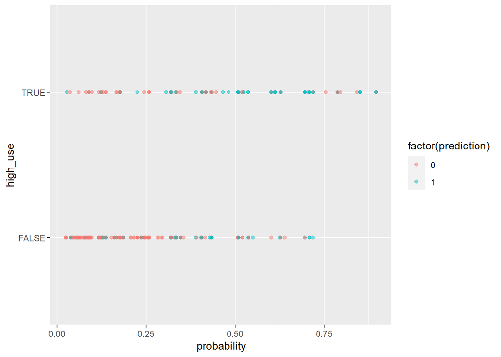

```r
# Plotting the predictions
ggplot(tb_alc_pred)+
  aes(x=probability,y=high_use,col=factor(prediction))+
  geom_point(alpha=0.5)
```

The plot shows each student as one dot; The upper line is those with a high alcohol usage, and the lower line is those witout a high alcohol usage. **Red** points are those predicted to **not** have a high usage, and **blue** points are those predicted to **have** a high usage. The x-axis shows the estimated probability of high usage taken from the model.

As for the comparison with a simple guessing strategy; I found the question unclear and decided not to spend time on it. Leaving this part blank here.

## 7: Cross validation

```r
# Setting up the loss function (same as in the exercise)
loss_func <- function(class, prob) {
  n_wrong <- abs(class - prob) > 0.5
  mean(n_wrong)
}

# Running a 10-fold cross validation
library(boot)
cv <- cv.glm(data = tb_alc, cost = loss_func, glmfit = model, K = 10)
```

Our cross validation tell us that our function had an error of 0.2513514, which is actually better than the one used in the exercise. Looks like we already found a model with a better predictive accuracy. `